# LASSO REGRESSION

MARIE NYAWAGA

2026-02-11

```r
setwd("C:/Users/MARIE_NYAWAGA/OneDrive/Documents")
```

```r
getwd()
```

```
## [1] "C:/Users/MARIE_NYAWAGA/OneDrive/Documents"
```

## Step 1: Load the dataset and necessary Libraries

```r
#step 1: Load the dataset and necessary Libraries
library(readxl)
library(dplyr)
data <- read_excel("Student health survey data.xlsx")

summary(data)
```

```
##       age             sex           incmnth         homecost
##  Min.   :17.00   Min.   :1.000   Min.   :    0   Min.   :   0.0
##  1st Qu.:18.00   1st Qu.:1.000   1st Qu.:    0   1st Qu.:   0.0
##  Median :18.00   Median :2.000   Median :  600   Median :   0.0
##  Mean   :20.51   Mean   :1.699   Mean   : 1058   Mean   : 362.6
##  3rd Qu.:21.00   3rd Qu.:2.000   3rd Qu.: 1400   3rd Qu.: 480.0
##  Max.   :48.00   Max.   :2.000   Max.   :10000   Max.   :7500.0
##
##    mobilecost       transport           food          entertain
##  Min.   :  0.00   Min.   :  0.00   Min.   :  0.00   Min.   :  0.00
##  1st Qu.:  0.00   1st Qu.: 10.00   1st Qu.: 20.25   1st Qu.:  0.00
##  Median : 30.00   Median : 25.00   Median : 50.00   Median : 20.00
##  Mean   : 43.23   Mean   : 42.45   Mean   : 76.25   Mean   : 38.69
##  3rd Qu.: 60.00   3rd Qu.: 60.00   3rd Qu.:100.00   3rd Qu.: 50.00
##  Max.   :600.00   Max.   :450.00   Max.   :500.00   Max.   :500.00
##
##       veg            fruit         medication         height
##  Min.   :0.000   Min.   :0.000   Min.   : 1.000   Min.   : 125.0
##  1st Qu.:2.000   1st Qu.:1.000   1st Qu.: 1.000   1st Qu.: 162.0
##  Median :3.000   Median :2.000   Median : 2.000   Median : 169.0
##  Mean   :2.835   Mean   :2.216   Mean   : 2.631   Mean   : 426.1
##  3rd Qu.:4.000   3rd Qu.:3.000   3rd Qu.: 2.000   3rd Qu.: 175.0
##  Max.   :6.000   Max.   :6.000   Max.   :99.000   Max.   :9999.0
##                                                   NA's   :1
##      weight
##  Min.   :  35.0
##  1st Qu.:  55.0
##  Median :  62.0
##  Mean   : 130.5
##  3rd Qu.:  74.0
##  Max.   :9999.0
##  NA's   :1
```

The dataset primarily includes **demographic**, **financial**, **dietary**, and health-related variables for students. Most students are young adults (median age: 18), with low monthly incomes (median: 600) and modest expenses on food, transport, and other needs. Dietary habits indicate low to moderate consumption of vegetables and fruits (means: ~2–3). However, there are **significant outliers** and errors in variables like height (max: 9999) and weight (max: 9999), as well as medication usage (max: 99), which require cleaning. Missing values in height and weight, along with the skewed distribution of income and expenses, highlight the need for further preprocessing to ensure accurate analysis.

## Step 2: Data cleaning

1. **`data_clean <- data %>%`**: Creates a new, cleaned version of the dataset called `data_clean` by applying several steps.
2. **`filter(height < 300, weight < 300)`**: Keeps only rows where:
   - Height is less than 300.
   - Weight is less than 300. This removes unrealistic or erroneous values.
3. **`na.omit()`**: Removes rows with missing values (`NA`) in any column, ensuring only complete data is kept.
4. **`summary(data_clean)`**: Provides an updated summary of the cleaned dataset, showing basic statistics (e.g., minimum, median, mean) and distributions for variables.

```r
data_clean <- data %>%
  filter(height < 300, weight < 300) %>%
  na.omit()
summary(data_clean)
```

```
##       age             sex           incmnth         homecost
##  Min.   :17.00   Min.   :1.000   Min.   :    0   Min.   :   0.0
##  1st Qu.:18.00   1st Qu.:1.000   1st Qu.:    0   1st Qu.:   0.0
##  Median :18.00   Median :2.000   Median :  600   Median :   0.0
##  Mean   :20.47   Mean   :1.702   Mean   : 1074   Mean   : 365.5
##  3rd Qu.:21.00   3rd Qu.:2.000   3rd Qu.: 1475   3rd Qu.: 480.0
##  Max.   :48.00   Max.   :2.000   Max.   :10000   Max.   :7500.0
##    mobilecost      transport           food          entertain
##  Min.   :  0.0   Min.   :  0.00   Min.   :  0.00   Min.   :  0.00
##  1st Qu.:  0.0   1st Qu.: 10.00   1st Qu.: 20.50   1st Qu.:  0.00
##  Median : 30.0   Median : 25.00   Median : 50.00   Median : 20.00
##  Mean   : 43.4   Mean   : 42.57   Mean   : 76.25   Mean   : 38.84
##  3rd Qu.: 60.0   3rd Qu.: 60.00   3rd Qu.:100.00   3rd Qu.: 50.00
##  Max.   :600.0   Max.   :450.00   Max.   :500.00   Max.   :500.00
##       veg            fruit         medication         height
##  Min.   :0.000   Min.   :0.000   Min.   : 1.000   Min.   :125.0
##  1st Qu.:2.000   1st Qu.:1.000   1st Qu.: 1.000   1st Qu.:161.0
##  Median :3.000   Median :2.000   Median : 2.000   Median :168.0
##  Mean   :2.856   Mean   :2.217   Mean   : 2.336   Mean   :168.3
##  3rd Qu.:4.000   3rd Qu.:3.000   3rd Qu.: 2.000   3rd Qu.:175.0
##  Max.   :6.000   Max.   :6.000   Max.   :97.000   Max.   :235.0
##      weight
##  Min.   : 35.00
##  1st Qu.: 55.00
##  Median : 62.00
##  Mean   : 65.34
##  3rd Qu.: 74.00
##  Max.   :135.00
```

This code performs data cleaning to handle missing values and remove outliers, such as unrealistic height/weight values (e.g., maximum values exaggerated to 9999). It then checks the key statistics of the cleaned data.

## Step 3:Defining predictor variables(x) and response variable(y)<-weight

This code defines the dependent variable (`y`) and predictor matrix (`x`). Using `data.matrix` ensures the predictors are in numerical form, suitable for computations.

```r
y <- data_clean$weight
x <- data.matrix(data_clean[, c('age', 'sex', 'incmnth', 'homecost','mobilecost','transport','food','entertain','veg','fruit','medication','height')])
```

## Step 4: Fitting the model and cross validation to find lambda value that minizes MSE

The cross-validation splits the data into training and validation sets multiple times to evaluate the model’s performance for different values of lambda.

```r
#Loading the glmnet Package and setting the random seed for reproducibility
library(glmnet)
set.seed(42)

# Fitting the Cross-Validated Lasso Model
cv_model <- cv.glmnet(x, y, alpha = 1)  #alpha = 1: Specifies Lasso regression (for Ridge regression, alpha = 0).
cv_model
```

```
##
## Call:  cv.glmnet(x = x, y = y, alpha = 1)
##
## Measure: Mean-Squared Error
##
##     Lambda Index Measure    SE Nonzero
## min 0.3248    35   157.7 23.23       9
## 1se 3.0295    11   177.6 20.77       3
```

## Interpretation

### **Measure**:

- The performance metric used is **Mean-Squared Error (MSE)**, which measures how well the model predicts the response variable.

### **Key Results**

#### **`min` (Lambda Minimum)**:

- **`Lambda`**: `0.3248`
  - This is the **optimal lambda value** that minimizes the cross-validated MSE.
- **`Index`**: `35`
  - The position of this lambda in the sequence of lambdas tested.
- **`Measure`**: `157.7`
  - The lowest Mean-Squared Error achieved at `lambda.min`.
- **`SE`**: `23.23`
  - The standard error of the MSE at `lambda.min`.
- **`Nonzero`**: `9`
  - The number of predictors (variables) with nonzero coefficients in the model at `lambda.min`.

#### **`1se` (Lambda 1 Standard Error Rule)**:

- **`Lambda`**: `3.0295`
  - A more conservative lambda value within **one standard error** of the minimum MSE.
- **`Index`**: `11`
  - The position of this lambda in the sequence of lambdas tested.
- **`Measure`**: `177.6`
  - The MSE at `lambda.1se`.
- **`SE`**: `20.77`
  - The standard error of the MSE at `lambda.1se`.
- **`Nonzero`**: `3`
  - The number of predictors with nonzero coefficients at `lambda.1se`.

### **Explanation**

1. **Lambda Selection**:
   - **`lambda.min`**: Results in the most accurate model with the lowest MSE, but it uses **9 variables**.
   - **`lambda.1se`**: Results in a simpler, more conservative model with fewer predictors (**3 variables**), sacrificing a bit of accuracy for simplicity and robustness.
2. **Model Choice**:
   - If accuracy is the priority, use **`lambda.min`**.
   - If simplicity and avoiding overfitting are more important, use **`lambda.1se`**.

## Step 5: Extract the results

     This code is used to extract and display key results from a Lasso regression model, specifically the optimal lambda value (penalty parameter) and the coefficients of the model at that lambda.
     1. **Optimal Lambda (`lambda.min`)**
        - This retrieves the lambda value that minimizes the Mean Squared Error (MSE) during cross-validation. It represents the best balance between bias and variance for the model.
        - Identifies the optimal amount of regularization to prevent overfitting.
     2. **Model Coefficients**
        - This extracts the coefficients of the predictors at the optimal lambda (`lambda.min`). Predictors with coefficients shrunk to zero are effectively excluded from the model.
        - Shows which predictors contribute to the response variable and their respective effect sizes, helping interpret the model’s insights.

```r
# Extract optimal lambda value
lambda_min <- cv_model$lambda.min

# Coefficients at the optimal lambda
coefficients <- coef(cv_model, s = "lambda.min")

# Print results
print(paste("Optimal Lambda: ", lambda_min))
```

```
## [1] "Optimal Lambda:  0.324848354509821"
```

```r
print("Coefficients at Optimal Lambda:")
```

```
## [1] "Coefficients at Optimal Lambda:"
```

```r
print(coefficients)
```

```
## 13 x 1 sparse Matrix of class "dgCMatrix"
##                        s1
## (Intercept) -2.054674e+01
## age          6.364471e-01
## sex         -7.995267e+00
## incmnth      .
## homecost     3.176177e-04
## mobilecost   1.985040e-02
## transport   -1.308468e-02
## food         4.915911e-03
## entertain    .
## veg          .
## fruit       -8.670179e-01
## medication   7.171238e-02
## height       5.194646e-01
```

## Interpretation:

1. The optimal lambda value is **0.3248**, minimizing the Mean Squared Error.
2. Non-zero coefficients show key contributors to the response variable include **age (+0.636)**, **height (+0.519)**, **sex (-7.995)**, and **fruit (-0.867)**, among others. Predictors like **income**, **entertainment**, and **vegetables** were excluded as they had no significant contribution under the Lasso penalty. This highlights the most impactful predictors while eliminating irrelevant ones.

## Step 6: Visualize results

[figure not shown]

```r
# Regularization Path with Adjusted Y-Axis for Better Visualization
plot(cv_model$glmnet.fit, xvar = "lambda", label = TRUE, lwd = 0.5,
     ylim = c(-9.5, 1))  # Adjust the y-axis limits as needed
title("Regularization Path (Coefficient Shrinkage)", line = 3)

legend("bottom",
       legend = rownames(coef(cv_model$glmnet.fit)),  # Coefficient names
       col = 1:10,  # Colors used for the lines
       lwd = 2,     # Line width
       cex = 0.4,   # Text size
       box.lty = 0,  # Remove box around legend
       ncol = 7)     # Number of columns in the legend
```

### Interpretation of the Regularization Path Graph

#### **X-Axis (Log Lambda)**:

- The x-axis represents the logarithm of the regularization parameter **λ**.
- As **λ** increases (moving to the right), the model applies a stronger penalty, forcing the coefficients to shrink towards zero.

#### **Y-Axis (Coefficients)**:

- The y-axis shows the coefficient values for each predictor variable in the model.
- Each line represents the evolution of a specific predictor’s coefficient as **λ** increases.

#### **Interpretation**:

- On the left (small **λ**), there is minimal regularization, meaning the model relies on all the predictors with large coefficients.
- As **λ** increases, the model penalizes less important predictors, forcing their coefficients toward zero.
- At higher values of **λ**, some predictors are entirely excluded from the model as their coefficients become exactly zero.

This behavior highlights the **Lasso** (Least Absolute Shrinkage and Selection Operator) method’s **variable selection** ability. It helps identify the most influential predictors while effectively eliminating irrelevant ones.

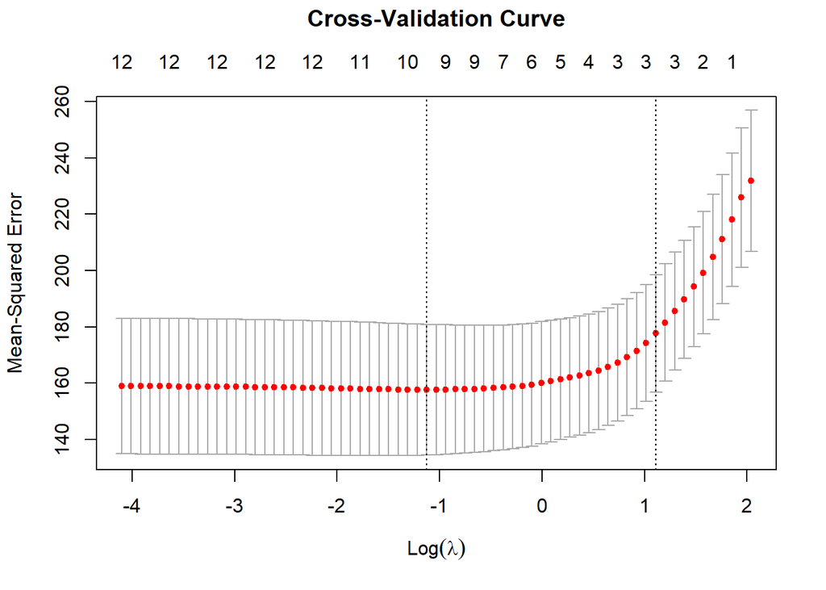

```r
# Cross-Validation Curve
plot(cv_model)
title("Cross-Validation Curve", line = 3)
```

### Interpretation of the Cross-Validation Curve

#### **X-Axis (Log(λ))**:

- The x-axis shows the logarithmic scale of the regularization parameter **λ**.
- Smaller values of **λ** (more negative **Log(λ)**) correspond to a more complex model with more features.
- Larger values of **λ** (positive **Log(λ)**) result in stronger regularization, shrinking the coefficients towards zero, which leads to simpler models.

#### **Y-Axis (Mean-Squared Error)**:

- The y-axis represents the mean-squared error (MSE) calculated during cross-validation.
- A lower MSE indicates better model performance on unseen data, meaning the model is generalizing well.

#### **Red Points and Error Bars**:

- The red points mark the mean MSE for each value of **λ**.
- The error bars represent the standard error of the MSE, indicating the variability and uncertainty of the model’s performance for each **λ**.

#### **Vertical Dashed Lines**:

- The left dashed line marks **λ_min**, which corresponds to the **λ** value that minimizes the MSE.
- The right dashed line represents **λ_1SE**, the largest **λ** within one standard error of the minimum MSE, which results in a simpler model.

#### **Interpretation**:

- **λ_min**: Choosing this value minimizes MSE, but can result in a more complex model with more variables.
- **λ_1SE**: This value provides a simpler model with fewer predictors, making it a more conservative choice. It tends to be preferred if the goal is to avoid overfitting.
- **Values smaller than λ_min**: These lead to more complex models and can cause overfitting, as the model starts to fit noise rather than the underlying patterns.
- **Values larger than λ_1SE**: These result in overly simple models with higher bias, reducing predictive power by excluding potentially important variables.

#### **For Loop for Efficient Model Fitting**:

- Using a **for loop** to fit the model for different response variables is an efficient way to avoid repetitive coding.
- The loop automates the process of fitting the model and generating results, saving time and ensuring consistency when analyzing multiple response variables.

This approach can be particularly useful when dealing with datasets containing several outcome variables, as it helps streamline the analysis process without manually fitting the model each time.

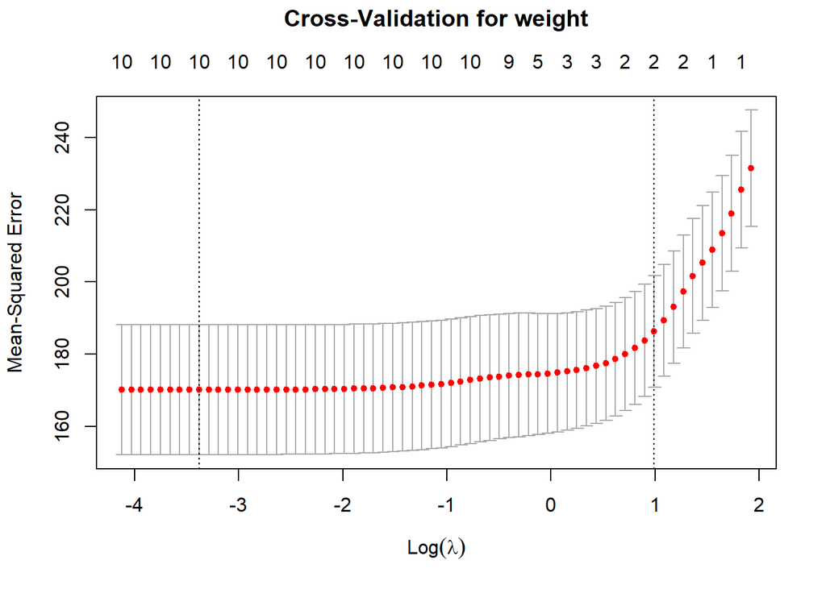

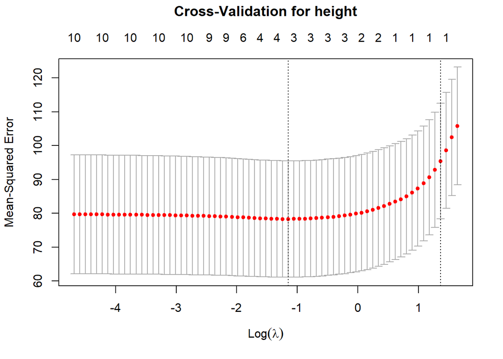

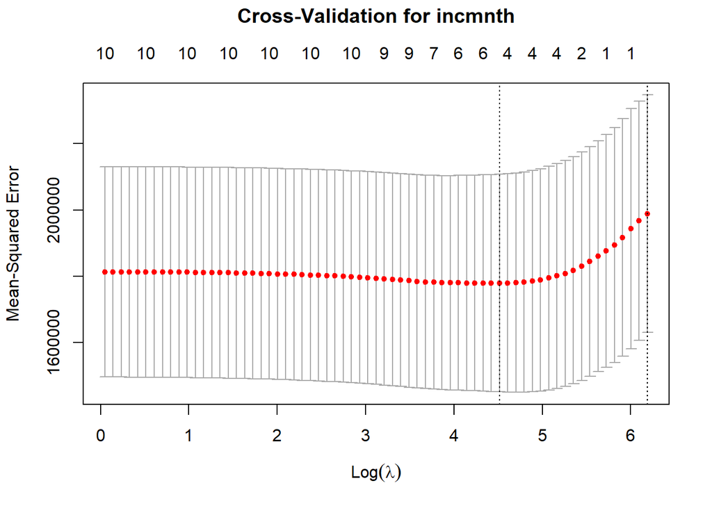

```r
# Response variables to analyze
response_vars <- c("weight", "height", "incmnth")

for (y_var in response_vars) {
  # Define response and predictors
  y <- data_clean[[y_var]]
  X <- model.matrix(~ age + sex + homecost + mobilecost +
                    transport + food + entertain + veg + fruit +
                    medication, data = data_clean)[, -1]

  # Fit Lasso model
  cv_model <- cv.glmnet(X, y, alpha = 1)

  # Plot the model for the current response variable
  plot(cv_model)

   # Add title with adjusted position
  title(main = paste("Cross-Validation for", y_var), line = 3)  # Adjust 'line' to move title upwards
}
```